# Fallstudie Textanalyse

MQM FS 2026 – Hausaufgabe 3

Sarah Inderbitzin, Andri Schneider

19.06.2026

# Ausgangslage und Story

Wir geniessen als Gesellschaft heute viele Services, die den Alltag bequemer gestalten. Die Smartphones werden von einem Grossteil der Personen immer bei sich getragen und bieten unterschiedliche Möglichkeiten für solche Services; Vom Geniessen verschiedenster Musik per Knopfdruck, über die Konnektivität mit Familie, Freunden, Arbeit und gefühlt dem Rest der Welt, bis hin zum Ersatz des Portemonnaies durch Digital-Wallet-Möglichkeiten von beispielsweise ID, Krankenkassenkarte und auch Zahlungsmöglichkeiten ist alles in dem unscheinbaren Handy enthalten. Ob das wirklich so toll ist und nur Positiven birgt, müssen alle für sich selbst bestimmen. Deswegen können digitale Zahlungsmittel wie TWINT Fluch und Segen zugleich sein. TWINT ist seit dessen Einführung für viele im Alltag zur Normalität geworden; Ultra praktisch muss kein Bargeld und keine EC-Karte zum einzukaufen mitgenommen werden und es kann auch mal spontan irgendwo etwas gekauft werden. Steht man aber an der Kasse und hat keinen Akku, kein Netz oder die App selbst hat ein Problem, ist das dann doch ziemlich ungünstig.

Somit ist das Potenzial für verärgerte Kundschaft nicht klein, welche dann teilweise auch ein Ventil für ihren Frust sucht. Dieses Ventil kann eine Rezension sein. Somit sind in den Rezensionen der Apps immer wieder geladene Texte der Kundschaft zu finden, bei der die App “im dümmsten Moment” nicht funktioniert. Auch wenn die App an sich grösstenteils sehr gut funktioniert und das auch in den Rezensionen zu lesen ist, sind genau solche Aussetzer wichtig zu erkennen.

Genau hier setzt unsere Analyse an. Eine einzelne Sternebewertung sagt zwar, ob jemand zufrieden war, aber nicht, warum. Wir fragen deshalb: Lassen sich aus den Texten der TWINT-Rezensionen systematisch jene Themen herauslesen, die hinter negativen Bewertungen stehen und unterscheiden sich diese sprachlich klar von den positiven? Wir erwarten erstens eine insgesamt eher positive bis polarisierte Bewertungsverteilung, wie sie für etablierte Alltags-Apps typisch ist.

Zweitens vermuten wir, dass sich negative Reviews weniger auf die Idee der App sondern eher auf konkrete Ausfälle beziehen; Begriffe rund um Login, Verbindung oder Zahlungsabbrüche dürften in den schlecht bewerteten Texten überdurchschnittlich häufig auftauchen. Ob sich diese Erwartung bestätigt und ob ein einfaches, interpretierbares Modell positive von negativen Reviews allein anhand des Textes trennen kann, prüfen wir in den nächsten Minuten.

# Daten

```
## Anzahl Texte:        1781
```

```
## Leere Texte:         0
```

```
## Anteil positiv:      0.67
```

```
## Wörter im Mittel:   17.38
```

```
## Anzahl Sprachen und deren Verteilung:
```

```
##
##        af   da   de   en   fr   it   nl   no   sv
##  123    4    2 1608   31    3    5    1    1    3
```

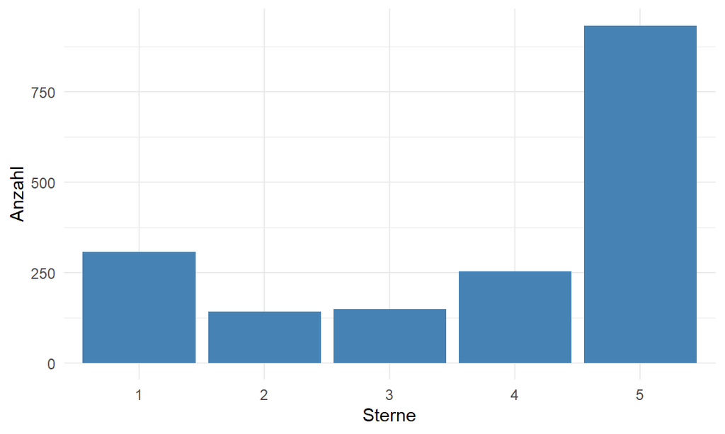

Der Datensatz umfasst 1’781 Reviews und keines davon ist leer. Die Reviews sind mit durchschnittlich 17 Wörtern eher kurz, was für App-Bewertungen aber typisch ist.

Die Rating-Labels sind folgendermassen verteilt: 67 % positiv (4–5 Sterne), 33 % negativ (1-3 Sterne). In der Grafik ist ersichtlich, dass die 5-Sternebewertung am häufigsten gegeben wird, gefolgt von einem Stern. Die restlichen Bewertungen (2-4) sind relativ gleichmässig verteilt im Mittelmass. Es sind mehrheitlich positive Bewertungen, aber es gibt genug negatives Material (rund ein Drittel), um Muster hinter schlechten Bewertungen herauszuarbeiten.

Circa 90% der Reviews wurden als Deutsch erkannt. Bei der Übersetzung wurde vom Google-Translator Englisch (31x), Französisch (3x) und Italienisch (3x) korrekt erkannt und ins deutsche übersetzt. Die restlichen erkannten Sprachen (Niederländisch, Dänisch, Französisch, Schwedisch, Norwegisch und Afrikanisch) sind bei genauerer Betrachtung falsch klassifiziert, da diese bereits im Original Deutsch waren; sie wurden trotzdem “übersetzt”. Zudem konnten einige Texte nicht erkannt werden (NaN). Diese waren entweder Hochdeutsch mit Schreibfehlern oder verhältnismässig vielen englischen Begriffen oder auf Schweizerdeutsch verfasst.

Folgend werden nur noch die originalen oder auf Deutsch übersetzten Texte verwendet. Aufgrund der geringen Anzahl der Schweizerdeutschen Texte werden diese nicht als entscheidend betrachtet und deswegen nicht noch separat übersetzt.

# Vorverarbeitung

```r
de_stop <- c("app", "twint", "ubs", stopwords(source = "snowball", language = "de"))

# --- udpipe-Modell laden------------------------
# Der Download legt eine .udpipe-Datei im Projektordner ab. Danach wird nur
# noch geladen -> beim Knitten nicht jedes Mal neu herunterladen.
ud_files <- list.files(pattern = "german-gsd.*\\.udpipe$")
if (length(ud_files) == 0) {
  model_file <- udpipe_download_model(language = "german-gsd")$file_model
} else {
  model_file <- ud_files[1]
}
ud_model <- udpipe_load_model(model_file)

# --- Annotation: Tokenisierung + POS + Lemma in einem Schritt ------------
anno <- udpipe_annotate(
  ud_model,
  x      = reviews$text,
  doc_id = as.character(reviews$doc_id),
  parser = "none"  #kein Dependency-Parsing nötig -> deutlich schneller.
) |>
  as.data.frame()

# --- Tokens aufbereiten ---------------------------------------------------
tokens <- anno |>
  filter(!upos %in% c("PUNCT", "SYM", "NUM", "X")) |>     # Satzzeichen/Zahlen/Symbole raus
  mutate(
    word  = str_to_lower(token),
    lemma = str_to_lower(coalesce(lemma, token))          # wenn kein Lemma vorhanden ist, nimmt es den Token selbst
  ) |>
  filter(!lemma %in% de_stop) |>                          # Stoppwörter auf Lemma-Ebene
  filter(str_detect(lemma, "[a-zäöüß]")) |>               # nur Lemmas nehmen, die auch tatsächlich Buchstaben enthalten
  left_join(reviews |> transmute(doc_id = as.character(doc_id), label),
            by = "doc_id") |>
  select(doc_id, label, word, lemma)

#nun wurden alle reviews in token (wörter) aufgesplittet und jedes wort hat das label positiv oder negativ
```

Satzzeichen, Symbole und Zahlen entfernen wir über die Wortart (`upos`) statt über eine Zeichenregel; das ist präziser als `strip_numeric`. Zahlen tragen in App-Reviews kaum inhaltliche Bedeutung (Sternangaben, Datums- und Versionsnummern) und fallen deshalb weg. Die Stoppwörter entfernen wir bewusst auf der Lemma-Ebene mit der Snowball-Liste für Deutsch: Da flektierte Funktionswörter wie “ist”, “war” oder “sind” alle auf das Lemma “sein” zurückgeführt werden, greift die Liste auf der Grundform zuverlässiger als auf der Oberflächenform. Dies ist ein konkreter Vorteil der Lemmatisierung. Zusätzlich ergänzen wir domänenspezifische Stopwörter wie `app`, `twint` und `ubs`, damit sehr häufige Marken-/Produktbegriffe die inhaltliche Trennung der Klassen nicht dominieren. Findet `udpipe` für ein Token kein Lemma (etwa bei Tippfehlern, englischen Begriffen oder Schweizerdeutsch), behalten wir die Oberflächenform, damit kein Token verloren geht.

Eine Filterung seltener Wörter nehmen wir an dieser Stelle nicht global vor: Sie erfolgt erst beim Aufbau der Feature-Matrix und ausschliesslich auf den Trainingsdaten, damit keine Testinformation einfliesst.

# Explorative Analyse

## Worthäufigkeiten

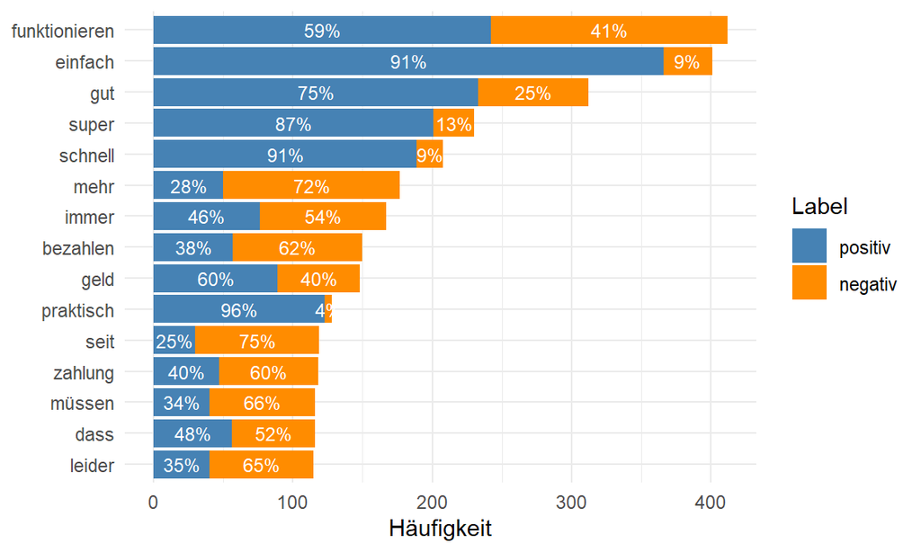

Häufigste Stems im Korpus

```r
# Top 15 Lemmas nach GESAMThäufigkeit bestimmen
top_n_lemma <- tokens |>
  count(lemma, sort = TRUE) |>
  slice_head(n = 15)

# Häufigkeiten je Lemma UND Label, nur für diese Top-15
top_lemma <- tokens |>
  filter(lemma %in% top_n_lemma$lemma) |> # nur die Top-15 Lemmas betrachten
  count(lemma, label) |>                  # Häufigkeit zählen für Lemma und Label
  mutate(label = factor(label, levels = c("positiv", "negativ"))) |> # Label-Reihenfolge für konsistente Farben
  group_by(lemma) |>
  mutate(pct = n / sum(n)) |>           # Anteil innerhalb des Balkens
  ungroup()

ggplot(top_lemma, aes(x = n, y = fct_reorder(lemma, n, .fun = sum), fill = label)) +
  geom_col(position = position_stack(reverse = TRUE)) +
  geom_text(aes(label = scales::percent(pct, accuracy = 1)),
            position = position_stack(vjust = 0.5, reverse = TRUE),
            color = "white", size = 3) +
  scale_fill_manual(values = c(positiv = "steelblue", negativ = "darkorange")) +
  labs(x = "Häufigkeit", y = NULL, fill = "Label") +
  theme_minimal()
```

Die häufigsten Lemmas bestätigen die erwartete Trennung bereits explorativ. Bedienbarkeitsbegriffe wie `einfach`, `super`, `schnell` und `praktisch` treten weit überdurchschnittlich in positiven Reviews auf, während sich Wörter rund um den Zahlungsvorgang (`zahlung`, `bezahlen`) sowie `seit` und `mehr` in den negativen Reviews konzentrieren. Zu beachten ist der Anteil von 67% positiven Reviews: Erst Wörter klar oberhalb dieser Schwelle sind tatsächlich positiv assoziiert weil die Datenbasis 2/3 positive Reviews enthält. So liegt `geld` mit 60% unter der Basis und ist damit eher negativ konnotiert. Sehr häufige, Wörter wie `funktionieren` (59%) tragen dagegen kaum zur Unterscheidung bei, vermutlich durch Formulierungen wie “funktioniert gut” oder “funktioniert nicht”.